# SemiMech Covid Forecasting

## Introduction

Please see influenza vignette for description

## Application to COVID-19 hospitalization forecasting

```r
library(stringr)
#setwd("../")
source('R/get_hhs.R')
forecast_date <- "2022-08-24"
hhs <- get_hhs()
hhs <- hhs[hhs$date < forecast_date,]
```

Let’s plot Texas (TX) as our example state.

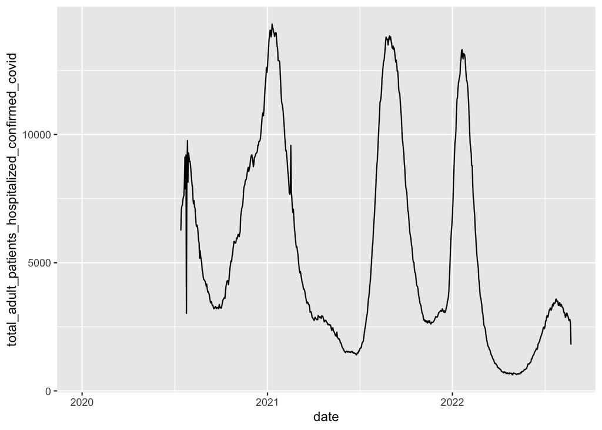

```r
library(ggplot2)
ggplot(hhs[hhs$state == "TX",],aes(x=date,y=total_adult_patients_hospitalized_confirmed_covid))+ geom_line()
```

Unlike influenza hospitalizations, COVID-19 does not have a set seasonality. To handle this we need to extract the “waves” that occur in COVID-19 data. To do this, we first smooth the time series and extract the derivative.

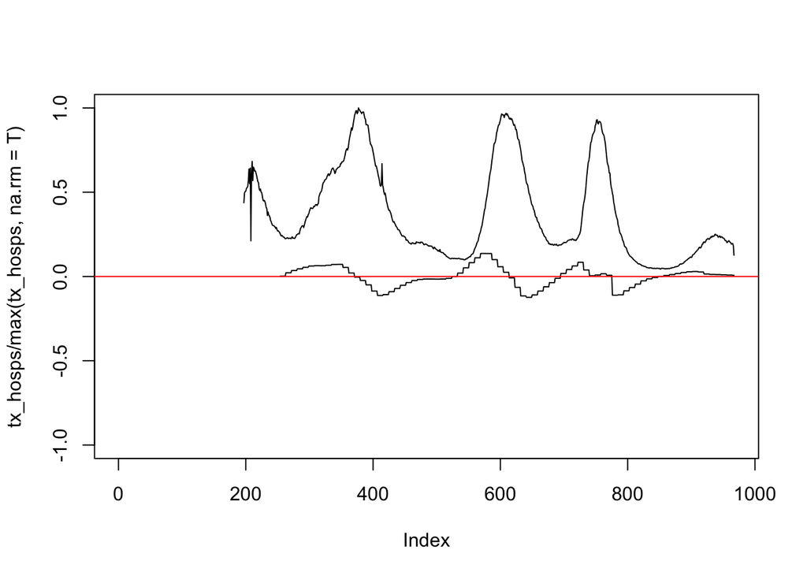

```r
tx_hosps <- hhs[hhs$state == "TX",]$total_adult_patients_hospitalized_confirmed_covid
smoothed_deriv <- c(0,diff(lowess(tx_hosps/max(tx_hosps,na.rm=T),f=.1)$y))
plot(tx_hosps/max(tx_hosps,na.rm=T),type='l',ylim=c(-1,1))
lines(10*smoothed_deriv,type='l')
abline(h=0,col='red')
```

As we can see from the plot, the points at which the derivative goes from negative to positive are good indicators of the beginning of a wave. Let’s now extract the waves.

```r
wave_starts <- c()

for (t in 2:length(smoothed_deriv)){
  if (!is.na(smoothed_deriv[t-1]) & !is.na(smoothed_deriv[t])){
    if (smoothed_deriv[t-1] < 0 & smoothed_deriv[t] >0){
      wave_starts <-c(wave_starts,t)
    }
  }
}

print (wave_starts)
```

```
## [1] 533 695 848
```

Lets add the wave starts to the plot we generated above.

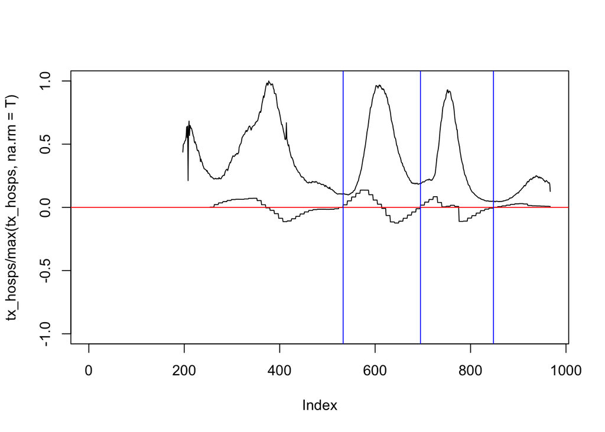

```r
plot(tx_hosps/max(tx_hosps,na.rm=T),type='l',ylim=c(-1,1))
lines(10*smoothed_deriv,type='l')
abline(h=0,col='red')

for (ws in wave_starts){
  abline(v=ws,col='blue')
}
```

We can see that the algorithm nicely identified two waves, except for the start of the wave, which we will handle later.

Let’s first extract the existing waves and plot them hierarchically.

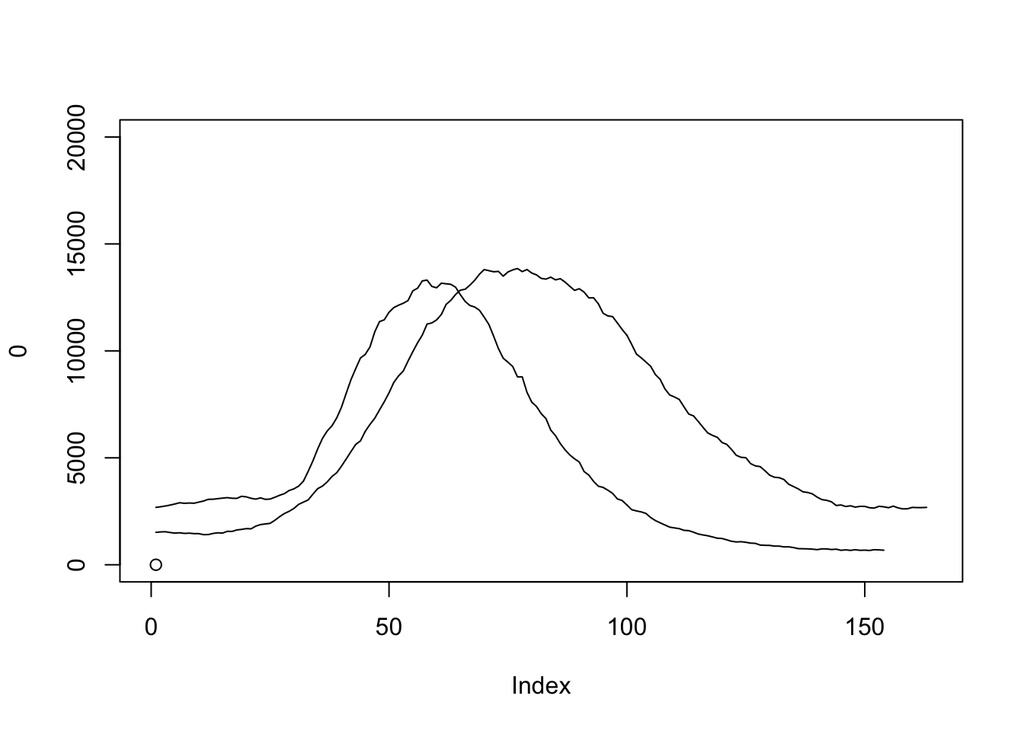

```r
wave_matrix <-matrix(NA,nrow=length(wave_starts)-1,ncol=1000)

for (wave_start in 2:length(wave_starts)){
  to_replace <- tx_hosps[wave_starts[wave_start-1]:wave_starts[wave_start]]
  while (length(to_replace) < 1000){
    to_replace <- c(to_replace,NA)
  }
  wave_matrix[wave_start-1,] <- to_replace
}


NAindex <-function(z){ min(which(is.na(z)))}

longest_wave_length <- max(apply(wave_matrix,1,NAindex))

wave_matrix <- wave_matrix[,1:longest_wave_length]

plot(0,xlim=c(0,longest_wave_length),ylim=c(0,20000))
for (row in 1:nrow(wave_matrix)){
  lines(wave_matrix[row,])
}
```

These are the historical waves we can use for training. We also need the current wave to fit.

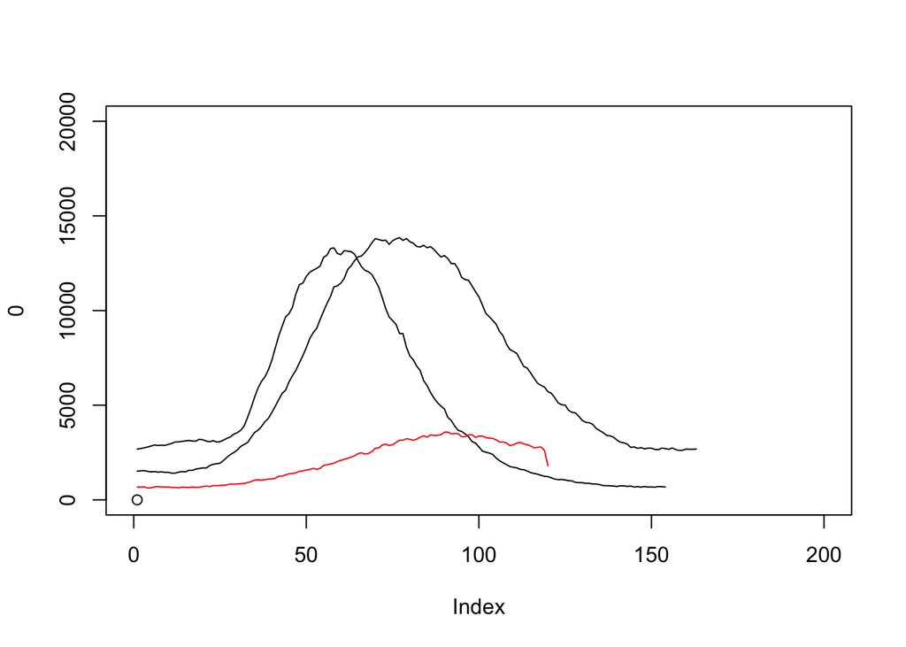

```r
current_wave <- tx_hosps[wave_starts[length(wave_starts)]:length(tx_hosps)]
plot(0,xlim=c(0,200),ylim=c(0,20000))
for (row in 1:nrow(wave_matrix)){
  lines(wave_matrix[row,])
}
lines(current_wave,col='red')
```

```r
source('R/semimech2.R')
```

```
## Linked to JAGS 4.3.0
```

```
## Loaded modules: basemod,bugs
```

```r
forecast <- run_semi_mech(season_past_matrix_hosp = wave_matrix,season_current_hosp =current_wave )
```

```
## module glm loaded
```

Now we have a forecast object, lets make some plots.

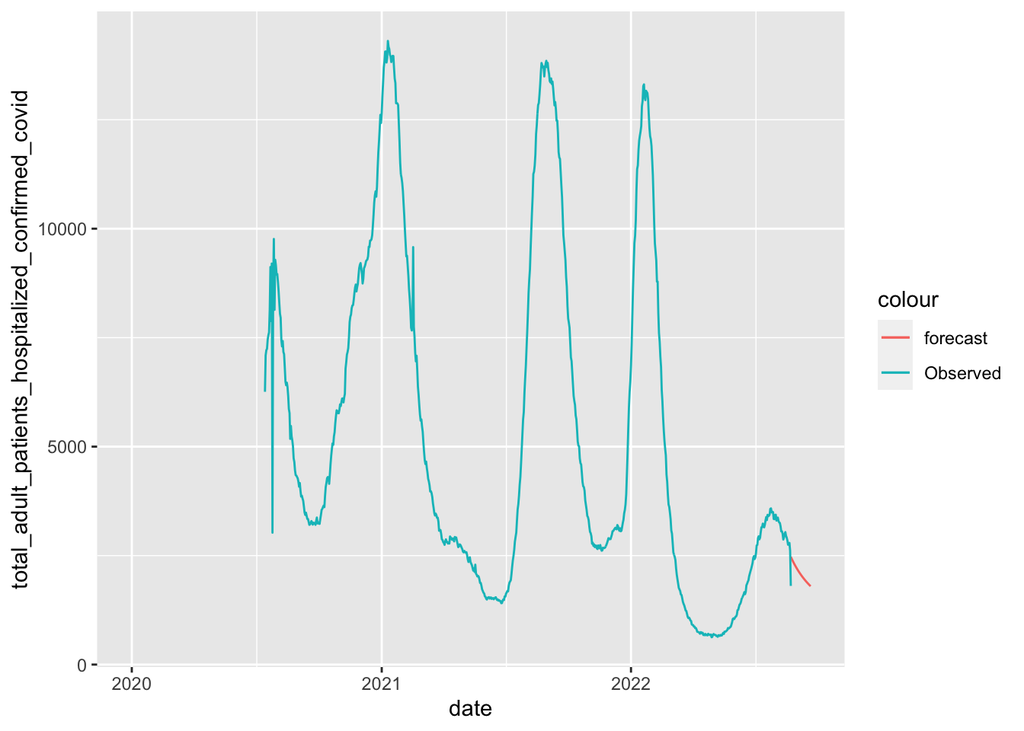

```r
forecast_dates <- seq(as.Date(tail(hhs$date,1)),as.Date(tail(hhs$date,1))+29,by="day")
forecast_df <- data.frame(date=forecast_dates,total_adult_patients_hospitalized_confirmed_covid=colMeans(forecast))


ggplot(forecast_df,aes(x=date,y=total_adult_patients_hospitalized_confirmed_covid,col='forecast')) + geom_line() +
  geom_line(data=hhs[hhs$state == "TX" & hhs$date < forecast_date,],aes(x=date,y=total_adult_patients_hospitalized_confirmed_covid,col='Observed'))
```